# Regressions_very_good

Tianran Zhang

6/22/2020

```r
load("../Data/ESP_reg.RData")
ESP.reg$health_status_verygood <-
  ifelse(ESP.reg$health_status %in% c("Excellent", "Very Good"),
         "Very Good", "Not Very Good")
ESP.reg$health_status_verygood <- as.factor(ESP.reg$health_status_verygood)
```

# Empire State Poll (ESP)

## Investigate the association between numeracy and self-reported health status

- Outcome: binary health status
1. Original Levels (Multi-level/Excellent/Very good/Good/Fair/Poor/Unknown)
2. Health status (Binary): Good VS. Not Very Good
- Predictor: numeracy score
- Covariates: gender, age, education, income, race, ethincity
- Interaction term: education & numeracy score

### Univariate Regressions

```r
univ <- function(var, y, dat){
  form = formula(paste0(y, " ~ ", var))
  logit = glm(form, data = dat, family = "binomial")
  OR = data.frame(exp(cbind(OR = coef(logit), confint(logit))))[-1, ]
  OR = cbind(var, OR, coef(summary(logit))[-1, 4])
  colnames(OR) <- c("Covariate", "OR", "2.5%", "97.5%", "p-val")
  OR$sig <- ifelse(OR$`p-val` < 0.05, "*", "")
  return(OR)
}

varlist1 <- c("numeracy", "gender", "age.cat", "educ",
              "income.cat", "race", "hisp")
univ_summary1 <- do.call(rbind.data.frame,
                        lapply(varlist1, univ,
                               y = "health_status_verygood",
                               dat = ESP.reg))
univ_summary1 %>%
  kable() %>%
  kable_styling()
```

Covariate

OR

2.5%

97.5%

p-val

sig

numeracy

numeracy

1.1468567

1.0928049

1.2060473

0.0000000

genderFemale

gender

0.9442095

0.7091863

1.2567810

0.6939783

age.cat21-44

age.cat

0.4571429

0.2299315

0.8855301

0.0219914

age.cat45-64

age.cat

0.5213245

0.2618971

1.0113031

0.0571343

age.cat65+

age.cat

0.4730435

0.2308241

0.9460776

0.0364658

educSome college or associate’s degree

educ

1.8087040

1.1879820

2.7741716

0.0060946

educBachelor’s degree or higher

educ

2.5235941

1.7261227

3.7292341

0.0000024

income.cat$50k-$100k

income.cat

2.2701758

1.5763582

3.2878501

0.0000121

income.cat$100k-$150k

income.cat

2.8991991

1.8237975

4.6354549

0.0000075

income.cat$150k+

income.cat

3.7360369

2.4344029

5.7832975

0.0000000

raceBlack

race

0.5397993

0.3399906

0.8430591

0.0076040

raceOther

race

0.5716350

0.3871872

0.8359910

0.0043296

hispNon-hispanic

hisp

1.6538682

1.1022843

2.5148970

0.0165404

```r
sig.var <- univ_summary1 %>%
  filter(`p-val` < 0.05) %>%
  select(Covariate)
sig.var <- unique(sig.var$Covariate)
sig.var <- paste0(sig.var, collapse = ', ')
```

### Multivariate Regressions

```r
n <- nrow(ESP.reg)

set.seed(135)
id <- sample(n, n * .6)
ESP.training <- ESP.reg[id, ]
ESP.test <- ESP.reg[-id, ]
```

**Unweighted Regressions**

```r
#ESP.reg$health_status_verygood <- relevel(ESP.reg$health_status_verygood,ref = "Very Good")
full1 <- glm(health_status_verygood ~ numeracy + gender + age.cat +
               educ + income.cat + race + hisp+
               educ:numeracy, data = ESP.reg, family = "binomial")
final1 <- step(full1, direction = "both", trace = 0)
# summary(final1)
fit1 <- glm(health_status_verygood ~ numeracy + age.cat + educ +
              income.cat, data = ESP.reg, family = "binomial")

multi_summary1 <- exp(cbind(coef(fit1), confint(fit1))[-1, ]) %>% as.data.frame()
colnames(multi_summary1)[1] <- "OR"
multi_summary1$sig <- ifelse(summary(fit1)$coefficients[-1, 4] < 0.05, "*", "")

kable(multi_summary1) %>%
  kable_styling()
```

OR

2.5 %

97.5 %

sig

numeracy

1.0947899

1.0389826

1.1554440

age.cat21-44

0.3294598

0.1583766

0.6676729

age.cat45-64

0.3392651

0.1622258

0.6911569

age.cat65+

0.3483808

0.1623785

0.7291487

educSome college or associate’s degree

1.6040101

1.0254275

2.5255488

educBachelor’s degree or higher

1.7375392

1.1265182

2.6992099

income.cat$50k-$100k

1.8463502

1.2557301

2.7252791

income.cat$100k-$150k

2.2330758

1.3648430

3.6680203

income.cat$150k+

2.7074081

1.6867088

4.3747272

```r
# power calculation
power1 <- powerSim(final1, nsim = 100,  progress = FALSE)
auc1 <- auc(ESP.reg$health_status_verygood, predict.glm(fit1, ESP.reg, type = "response"))

# Calculate error rate
fit1.train <- glm(health_status_verygood ~ numeracy + age.cat + educ +
              income.cat, data = ESP.training, family = "binomial")
pred1 <- predict(fit1.train, ESP.test, type = "response")
pred1 <- ifelse(pred1 > .5, "Very Good", "Not Very Good")
err1 <- mean(pred1 != ESP.test$health_status_verygood)
```

Step-wise selection method was conducted. The final model has four significant predictors: numeracy, age, education, and income. The power for our final model is 0.9, with an AUC of 0.6699251. The prediction error rate is 0.359.

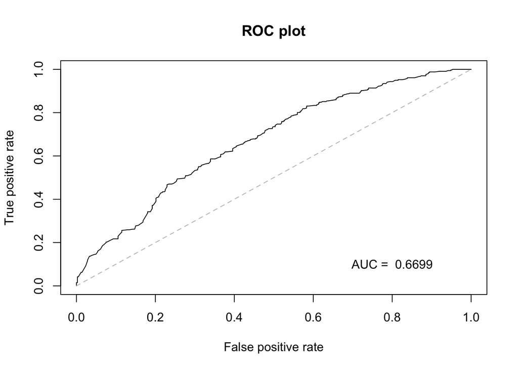

```r
# ROC curve
rocplot <- function(truth, pred, ...){
  predob = prediction(pred, truth)
  perf = performance(predob, "tpr", "fpr")
  plot(perf, colorize=F, ...)
  area = auc(truth, pred)
  area = format(round(area, 4), nsmall = 4)
  text(x = .8, y = .1, labels = paste("AUC = ", area))
  segments(x0 = 0, y0 = 0, x1 = 1, y1 = 1, col = "gray", lty = 2)
}

rocplot(ESP.reg$health_status_verygood, predict.glm(fit1, ESP.reg, type = "response"), title = "ROC plot")
title(main = "ROC plot")
```

**Weighted Regressions**  
Based on the comparison table between ESP and NYS, education, income and race are three variables that have different different distributions in ESP data and NYS dataset. Add weights to adjust the proportion of these three variables and refit the multi-regression model, education and income are significant covariates. So, we only add weights to adjust the proportion of education and income. Weights are calculated based on manual iterative solution.

```r
# This function generate survey weights automatically
surv.wt <- function(x, w, col_name){
  # x: dataset of interest
  # w: NYS percentages
  # cpl_pos: column number of the variable to be weighted
  # col_name: name of the variable to be weighted
  #x <- ESP.weighted; w <- wt.edu; col_pos<- 5; col_name <- "educ"
  col_pos <- which(colnames(x) == col_name)
  x1 <- x %>%
    group_by_at(col_pos) %>%
    summarise(wt = sum(wt)/nrow(x)) %>%
    mutate(wt_new = w/wt) %>%
    select(-wt)

  merge(x, x1, by = col_name) %>%
    mutate(wt = wt * wt_new) %>%
    select(-wt_new)
}

# This function check if weighted ESP is significant different
# compared to NYS

fisher.sig <- function(x, col_name, w2){
  col_pos <- which(colnames(x) == col_name)
  x1 <- x %>%
    group_by_at(col_pos) %>%
    summarise(w = sum(wt))
  fisher.test(matrix(c(x1$w, w2), byrow = T, ncol = length(w2)),
              simulate.p.value = T)$p.value
}
```

```r
# Manully input the NYS education level proportion and hispanic proportion

ESP.weighted <- ESP.reg %>%
  mutate(wt = 1)

wt.educ <- c(97506, 69577, 83478)
wt.income <- c(51303, 64932, 19158, 19930)
wt.race <- c(13559, 3424, 2471)

# 1st iterative
ESP.weighted <- surv.wt(ESP.weighted, wt.educ/sum(wt.educ), "educ")
ESP.weighted <- surv.wt(ESP.weighted, wt.income/sum(wt.income), "income.cat")
# ESP.weighted <- surv.wt(ESP.weighted, wt.race/sum(wt.race), "race")

# Check p-values for fisher.tests
# fisher.sig(ESP.weighted, "educ", wt.educ)
# fisher.sig(ESP.weighted, "income.cat", wt.income)
# fisher.sig(ESP.weighted, "race", wt.race)
```

```r
full2 <- glm(health_status_verygood ~ numeracy + gender + age.cat +
               educ + income.cat + race + hisp, weights = wt,
             data = ESP.weighted, family = "binomial")
final2 <- step(full2, direction = "both", trace = 0)
# summary(final2)
fit2 <- glm(health_status_verygood ~ numeracy + age.cat +
               educ + income.cat + hisp, weights = wt,
             data = ESP.weighted, family = "binomial")
fit2.unweight <- glm(health_status_verygood ~ numeracy + age.cat +
               educ + income.cat +hisp,
               data = ESP.weighted, family = "binomial")

multi_summary2 <- exp(cbind(coef(fit2), confint(fit2))[-1, ]) %>% as.data.frame()
colnames(multi_summary2)[1] <- "OR"
multi_summary2$sig <- ifelse(summary(fit2)$coefficients[-1, 4] < 0.05, "*", "")

# power calculation
power2 <- powerSim(fit2, sim = fit2.unweight, nsim = 1000,
                   progress = FALSE)
auc2 <- auc(ESP.weighted$health_status_verygood, predict.glm(fit2, ESP.weighted, weights = wt, type = "response"))

kable(multi_summary2) %>%
  kable_styling()
```

OR

2.5 %

97.5 %

sig

numeracy

1.1069204

1.0512009

1.1675782

age.cat21-44

0.4154830

0.2195783

0.7798377

age.cat45-64

0.4411350

0.2313277

0.8336240

age.cat65+

0.4509609

0.2292524

0.8794236

educSome college or associate’s degree

1.5623745

1.0541715

2.3186946

educBachelor’s degree or higher

1.5622148

1.0452945

2.3369643

income.cat$50k-$100k

1.7972576

1.2331898

2.6320988

income.cat$100k-$150k

2.3798450

1.4128343

4.0261408

income.cat$150k+

2.7879245

1.6332418

4.7973532

hispNon-hispanic

1.4151412

0.9229955

2.1944940

```r
# lastResult()$error

# Calculate error rate
fit2.train <- glm(health_status_verygood ~ numeracy + age.cat +
               educ + income.cat +hisp, weights = wt,
             data = ESP.weighted[id, ], family = "binomial")
pred2 <- predict(fit2.train, ESP.test, type = "response")
pred2 <- ifelse(pred2 > .5, "Very Good", "Not Very Good")
err2 <- mean(pred2 != ESP.test$health_status_verygood)
```

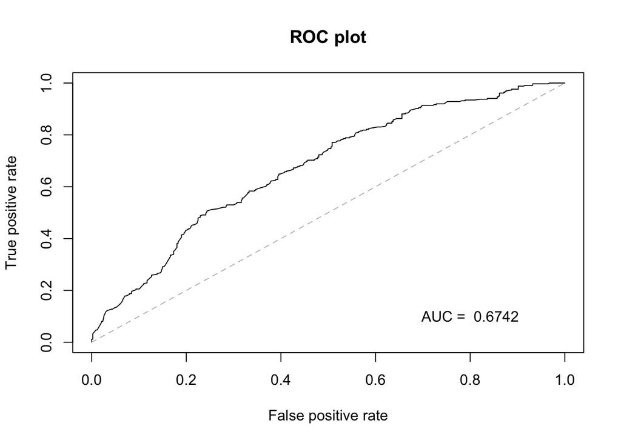

```r
# ROC curve
rocplot(ESP.weighted$health_status_verygood, predict.glm(fit2, ESP.weighted, weights = wt, type = "response"), title = "ROC plot")
title(main = "ROC plot")
```

# Summary

## ESP

```r
ESP_h1 <- c("health status: Good vs Not Very Good", "",
            round(auc1[1], 3),
            power1$x/power1$n, round(err1, 4), "\\*","", "\\*","\\*",
            "\\*","\\*", "\\*")
ESP_h2 <- c("health status: Good vs Not Very Good",
            "education, income", round(auc2[1], 3),
            power2$x/power2$n, round(err2, 4), "\\*", "", "\\*","\\*",
            "\\*","", "\\*")

ESP.result <- data.frame(ESP_h1, ESP_h2) %>% t() %>% as.data.frame()
rownames(ESP.result) <- NULL
colnames(ESP.result) <- c("Outcome", "Adjusted covariates", "AUC", "Power", "Prediction Error Rate", "numeracy", "gender", "age", "educ", "income", "race", "hisp")
ESP.result %>%
  kable(caption = "ESP's multivariates regression summary") %>%
  kable_styling() %>%
  add_header_above(c("Response" = 1, "Weights" = 1, "Performance"=3,"Predictor"=1,"Covariates"=6))
```

ESP’s multivariates regression summary

[output not shown]